# Problem Statement - Thera Bank Persnal Loan Modelling Project

### Importing libraries and dataset

```python
import numpy as np
import pandas as pd
import re
import seaborn as sns
import matplotlib.pyplot as plt
df = pd.read_csv('Bank_Personal_Loan_Modelling.csv')
```

### Check datatype

```python
df.dtypes
```

```
ID                      int64
Age                     int64
Experience              int64
Income                  int64
ZIP Code                int64
Family                  int64
CCAvg                 float64
Education               int64
Mortgage                int64
Personal Loan           int64
Securities Account      int64
CD Account              int64
Online                  int64
CreditCard              int64
dtype: object
```

### Statistical Summary

Here we can see that Experience column has min value as negative which is not possible because number of experience should be greater than or equal to zero.

Moreover, we have some categorical variables so for them the stats is not that meaningful. However, there are numeric columns such as Experience, Income, Family, CCAvg, Mortgage, CD account so we can get some idea with the below 5 points summary.

```python
df.describe()
```

|  | ID | Age | Experience | Income | ZIP Code | Family | CCAvg | Education | Mortgage | Personal Loan | Securities Account | CD Account | Online | CreditCard |
| --- | --- | --- | --- | --- | --- | --- | --- | --- | --- | --- | --- | --- | --- | --- |
| count | 5000.000000 | 5000.000000 | 5000.000000 | 5000.000000 | 5000.000000 | 5000.000000 | 5000.000000 | 5000.000000 | 5000.000000 | 5000.000000 | 5000.000000 | 5000.00000 | 5000.000000 | 5000.000000 |
| mean | 2500.500000 | 45.338400 | 20.104600 | 73.774200 | 93152.503000 | 2.396400 | 1.937938 | 1.881000 | 56.498800 | 0.096000 | 0.104400 | 0.06040 | 0.596800 | 0.294000 |
| std | 1443.520003 | 11.463166 | 11.467954 | 46.033729 | 2121.852197 | 1.147663 | 1.747659 | 0.839869 | 101.713802 | 0.294621 | 0.305809 | 0.23825 | 0.490589 | 0.455637 |
| min | 1.000000 | 23.000000 | -3.000000 | 8.000000 | 9307.000000 | 1.000000 | 0.000000 | 1.000000 | 0.000000 | 0.000000 | 0.000000 | 0.00000 | 0.000000 | 0.000000 |
| 25% | 1250.750000 | 35.000000 | 10.000000 | 39.000000 | 91911.000000 | 1.000000 | 0.700000 | 1.000000 | 0.000000 | 0.000000 | 0.000000 | 0.00000 | 0.000000 | 0.000000 |
| 50% | 2500.500000 | 45.000000 | 20.000000 | 64.000000 | 93437.000000 | 2.000000 | 1.500000 | 2.000000 | 0.000000 | 0.000000 | 0.000000 | 0.00000 | 1.000000 | 0.000000 |
| 75% | 3750.250000 | 55.000000 | 30.000000 | 98.000000 | 94608.000000 | 3.000000 | 2.500000 | 3.000000 | 101.000000 | 0.000000 | 0.000000 | 0.00000 | 1.000000 | 1.000000 |
| max | 5000.000000 | 67.000000 | 43.000000 | 224.000000 | 96651.000000 | 4.000000 | 10.000000 | 3.000000 | 635.000000 | 1.000000 | 1.000000 | 1.00000 | 1.000000 | 1.000000 |

```python
df.shape
```

```
(5000, 14)
```

```python
df.dtypes
```

```
ID                      int64
Age                     int64
Experience              int64
Income                  int64
ZIP Code                int64
Family                  int64
CCAvg                 float64
Education               int64
Mortgage                int64
Personal Loan           int64
Securities Account      int64
CD Account              int64
Online                  int64
CreditCard              int64
dtype: object
```

Here we can see that there are around 52 entries under the Experience column with values less than 0.

```python
print("Experience column array:-",str(df['Experience'].unique())+'\n')
print('Number of values less than zero under Experience column:', df[df['Experience']<0]['Experience'].count())
```

```
Experience column array:- [ 1 19 15  9  8 13 27 24 10 39  5 23 32 41 30 14 18 21 28 31 11 16 20 35
  6 25  7 12 26 37 17  2 36 29  3 22 -1 34  0 38 40 33  4 -2 42 -3 43]

Number of values less than zero under Experience column: 52
```

```python
# Calculating Experience mean excluding negative values, so that it can be used for imputation.
experience_mean = df[df['Experience']>=0]['Experience'].mean()
df.loc[df['Experience']<0,'Experience']=experience_mean

df['Experience'] = df['Experience'].round(2)
```

Check Null values in the DataFrame

```python
df.isnull().sum()
```

```
ID                    0
Age                   0
Experience            0
Income                0
ZIP Code              0
Family                0
CCAvg                 0
Education             0
Mortgage              0
Personal Loan         0
Securities Account    0
CD Account            0
Online                0
CreditCard            0
dtype: int64
```

```python
# Number of unique Values in each column
for col in df.columns:
    print(col)
    print(df[col].unique())
    print('Number of unique values in',col,'column:', len(df[col].unique()))
    print()
```

```
ID
[   1    2    3 ... 4998 4999 5000]
Number of unique values in ID column: 5000

Age
[25 45 39 35 37 53 50 34 65 29 48 59 67 60 38 42 46 55 56 57 44 36 43 40
 30 31 51 32 61 41 28 49 47 62 58 54 33 27 66 24 52 26 64 63 23]
Number of unique values in Age column: 45

Experience
[ 1.   19.   15.    9.    8.   13.   27.   24.   10.   39.    5.   23.
 32.   41.   30.   14.   18.   21.   28.   31.   11.   16.   20.   35.
  6.   25.    7.   12.   26.   37.   17.    2.   36.   29.    3.   22.
 20.33 34.    0.   38.   40.   33.    4.   42.   43.  ]
Number of unique values in Experience column: 45

Income
[ 49  34  11 100  45  29  72  22  81 180 105 114  40 112 130 193  21  25
  63  62  43 152  83 158  48 119  35  41  18  50 121  71 141  80  84  60
 132 104  52 194   8 131 190  44 139  93 188  39 125  32  20 115  69  85
 135  12 133  19  82 109  42  78  51 113 118  64 161  94  15  74  30  38
   9  92  61  73  70 149  98 128  31  58  54 124 163  24  79 134  23  13
 138 171 168  65  10 148 159 169 144 165  59  68  91 172  55 155  53  89
  28  75 170 120  99 111  33 129 122 150 195 110 101 191 140 153 173 174
  90 179 145 200 183 182  88 160 205 164  14 175 103 108 185 204 154 102
 192 202 162 142  95 184 181 143 123 178 198 201 203 189 151 199 224 218]
Number of unique values in Income column: 162

ZIP Code
[91107 90089 94720 94112 91330 92121 91711 93943 93023 94710 90277 93106
 94920 91741 95054 95010 94305 91604 94015 90095 91320 95521 95064 90064
 94539 94104 94117 94801 94035 92647 95814 94114 94115 92672 94122 90019
 95616 94065 95014 91380 95747 92373 92093 94005 90245 95819 94022 90404
 93407 94523 90024 91360 95670 95123 90045 91335 93907 92007 94606 94611
 94901 92220 93305 95134 94612 92507 91730 94501 94303 94105 94550 92612
 95617 92374 94080 94608 93555 93311 94704 92717 92037 95136 94542 94143
 91775 92703 92354 92024 92831 92833 94304 90057 92130 91301 92096 92646
 92182 92131 93720 90840 95035 93010 94928 95831 91770 90007 94102 91423
 93955 94107 92834 93117 94551 94596 94025 94545 95053 90036 91125 95120
 94706 95827 90503 90250 95817 95503 93111 94132 95818 91942 90401 93524
```

[output cut: 77 more lines]

```
Securities Account
[1 0]
Number of unique values in Securities Account column: 2

CD Account
[0 1]
Number of unique values in CD Account column: 2

Online
[0 1]
Number of unique values in Online column: 2

CreditCard
[0 1]
Number of unique values in CreditCard column: 2
```

```python
print('Number of people with zero Mortgage:',df.loc[df['Mortgage']==0,'Mortgage'].count())
```

```
Number of people with zero Mortgage: 3462
```

```python
print('Number of people with zero credit card spending per month:',df.loc[df['CCAvg']==0,'CCAvg'].count())
```

```
Number of people with zero credit card spending per month: 106
```

```python
df.loc[:,['Personal Loan','Securities Account','CD Account', 'Online','CreditCard', 'Education']].count()
```

```
Personal Loan         5000
Securities Account    5000
CD Account            5000
Online                5000
CreditCard            5000
Education             5000
dtype: int64
```

```python
df.columns
```

```
Index(['ID', 'Age', 'Experience', 'Income', 'ZIP Code', 'Family', 'CCAvg',
       'Education', 'Mortgage', 'Personal Loan', 'Securities Account',
       'CD Account', 'Online', 'CreditCard'],
      dtype='object')
```

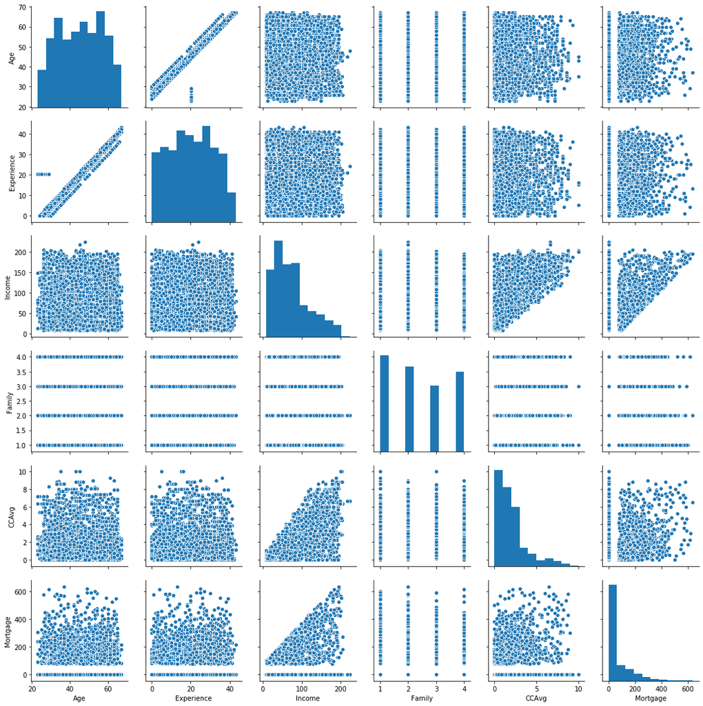

```python
sns.pairplot(df[['Age', 'Experience', 'Income', 'Family', 'CCAvg',
     'Mortgage']])
```

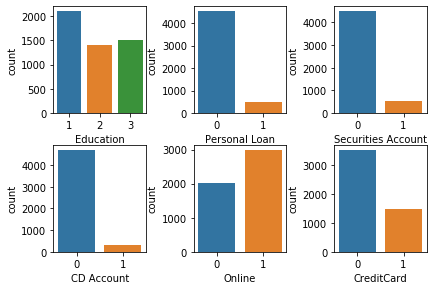

```python
# plotting category variables
fig, ax =plt.subplots(2,3)

plt.tight_layout()
sns.countplot(df['Education'], ax=ax[0,0])
sns.countplot(df['Personal Loan'], ax=ax[0,1])
sns.countplot(df['Securities Account'], ax=ax[0,2])
sns.countplot(df['CD Account'], ax=ax[1,0])
sns.countplot(df['Online'], ax=ax[1,1])
sns.countplot(df['CreditCard'], ax=ax[1,2])
```

```python
# converting numbers into labels under education column

df.loc[df['Education']==1,'Education']='Undergrad'
df.loc[df['Education']==2,'Education']='Graduate'
df.loc[df['Education']==3,'Education']='Advanced/Professional'
df['Education'].unique()
```

```
array(['Undergrad', 'Graduate', 'Advanced/Professional'], dtype=object)
```

```python
n_true = len(df.loc[df['Personal Loan'] == 1])
n_false = len(df.loc[df['Personal Loan'] == 0])
print("Number of true cases: {0} ({1:2.2f}%)".format(n_true, (n_true / (n_true + n_false)) * 100 ))
print("Number of false cases: {0} ({1:2.2f}%)".format(n_false, (n_false / (n_true + n_false)) * 100))
```

```
Number of true cases: 480 (9.60%)
Number of false cases: 4520 (90.40%)
```

```python
df_for_model = pd.get_dummies(df, columns=['Education']) #This function does One-Hot-Encoding on categorical text
```

```python
df_for_model.drop(columns=['ID','ZIP Code'],inplace=True)
```

```python
df_for_model
```

|  | Age | Experience | Income | Family | CCAvg | Mortgage | Personal Loan | Securities Account | CD Account | Online | CreditCard | Education_Advanced/Professional | Education_Graduate | Education_Undergrad |
| --- | --- | --- | --- | --- | --- | --- | --- | --- | --- | --- | --- | --- | --- | --- |
| 0 | 25 | 1.0 | 49 | 4 | 1.6 | 0 | 0 | 1 | 0 | 0 | 0 | 0 | 0 | 1 |
| 1 | 45 | 19.0 | 34 | 3 | 1.5 | 0 | 0 | 1 | 0 | 0 | 0 | 0 | 0 | 1 |
| 2 | 39 | 15.0 | 11 | 1 | 1.0 | 0 | 0 | 0 | 0 | 0 | 0 | 0 | 0 | 1 |
| 3 | 35 | 9.0 | 100 | 1 | 2.7 | 0 | 0 | 0 | 0 | 0 | 0 | 0 | 1 | 0 |
| 4 | 35 | 8.0 | 45 | 4 | 1.0 | 0 | 0 | 0 | 0 | 0 | 1 | 0 | 1 | 0 |
| ... | ... | ... | ... | ... | ... | ... | ... | ... | ... | ... | ... | ... | ... | ... |
| 4995 | 29 | 3.0 | 40 | 1 | 1.9 | 0 | 0 | 0 | 0 | 1 | 0 | 1 | 0 | 0 |
| 4996 | 30 | 4.0 | 15 | 4 | 0.4 | 85 | 0 | 0 | 0 | 1 | 0 | 0 | 0 | 1 |
| 4997 | 63 | 39.0 | 24 | 2 | 0.3 | 0 | 0 | 0 | 0 | 0 | 0 | 1 | 0 | 0 |
| 4998 | 65 | 40.0 | 49 | 3 | 0.5 | 0 | 0 | 0 | 0 | 1 | 0 | 0 | 1 | 0 |
| 4999 | 28 | 4.0 | 83 | 3 | 0.8 | 0 | 0 | 0 | 0 | 1 | 1 | 0 | 0 | 1 |

5000 rows × 14 columns

```python
df_for_model.columns
```

```
Index(['Age', 'Experience', 'Income', 'Family', 'CCAvg', 'Mortgage',
       'Personal Loan', 'Securities Account', 'CD Account', 'Online',
       'CreditCard', 'Education_Advanced/Professional', 'Education_Graduate',
       'Education_Undergrad'],
      dtype='object')
```

```python
from sklearn.preprocessing import StandardScaler

scalar_columns = ['Age', 'Experience', 'Income', 'Family', 'CCAvg', 'Mortgage',
       'Securities Account', 'CD Account', 'Online',
       'CreditCard', 'Education_Advanced/Professional', 'Education_Graduate',
       'Education_Undergrad']
std_scale = StandardScaler()

df_std = std_scale.fit_transform(df_for_model[scalar_columns])

df_std = pd.DataFrame(data=df_std, columns=scalar_columns, index=df_for_model.index)
df_std
```

|  | Age | Experience | Income | Family | CCAvg | Mortgage | Securities Account | CD Account | Online | CreditCard | Education_Advanced/Professional | Education_Graduate | Education_Undergrad |
| --- | --- | --- | --- | --- | --- | --- | --- | --- | --- | --- | --- | --- | --- |
| 0 | -1.774417 | -1.718030 | -0.538229 | 1.397414 | -0.193385 | -0.555524 | 2.928915 | -0.25354 | -1.216618 | -0.645314 | -0.654965 | -0.624538 | 1.177071 |
| 1 | -0.029524 | -0.118294 | -0.864109 | 0.525991 | -0.250611 | -0.555524 | 2.928915 | -0.25354 | -1.216618 | -0.645314 | -0.654965 | -0.624538 | 1.177071 |
| 2 | -0.552992 | -0.473791 | -1.363793 | -1.216855 | -0.536736 | -0.555524 | -0.341423 | -0.25354 | -1.216618 | -0.645314 | -0.654965 | -0.624538 | 1.177071 |
| 3 | -0.901970 | -1.007036 | 0.569765 | -1.216855 | 0.436091 | -0.555524 | -0.341423 | -0.25354 | -1.216618 | -0.645314 | -0.654965 | 1.601185 | -0.849566 |
| 4 | -0.901970 | -1.095911 | -0.625130 | 1.397414 | -0.536736 | -0.555524 | -0.341423 | -0.25354 | -1.216618 | 1.549632 | -0.654965 | 1.601185 | -0.849566 |
| ... | ... | ... | ... | ... | ... | ... | ... | ... | ... | ... | ... | ... | ... |
| 4995 | -1.425438 | -1.540282 | -0.733757 | -1.216855 | -0.021710 | -0.555524 | -0.341423 | -0.25354 | 0.821951 | -0.645314 | 1.526798 | -0.624538 | -0.849566 |
| 4996 | -1.338194 | -1.451407 | -1.276892 | 1.397414 | -0.880087 | 0.280238 | -0.341423 | -0.25354 | 0.821951 | -0.645314 | -0.654965 | -0.624538 | 1.177071 |
| 4997 | 1.540880 | 1.659190 | -1.081363 | -0.345432 | -0.937312 | -0.555524 | -0.341423 | -0.25354 | -1.216618 | -0.645314 | 1.526798 | -0.624538 | -0.849566 |
| 4998 | 1.715370 | 1.748064 | -0.538229 | 0.525991 | -0.822862 | -0.555524 | -0.341423 | -0.25354 | 0.821951 | -0.645314 | -0.654965 | 1.601185 | -0.849566 |
| 4999 | -1.512683 | -1.451407 | 0.200434 | 0.525991 | -0.651186 | -0.555524 | -0.341423 | -0.25354 | 0.821951 | 1.549632 | -0.654965 | -0.624538 | 1.177071 |

5000 rows × 13 columns

```python
df_for_model.drop(columns=scalar_columns, inplace=True)
df_for_model = pd.concat([df_for_model,df_std],axis=1)
df_for_model
```

|  | Personal Loan | Age | Experience | Income | Family | CCAvg | Mortgage | Securities Account | CD Account | Online | CreditCard | Education_Advanced/Professional | Education_Graduate | Education_Undergrad |
| --- | --- | --- | --- | --- | --- | --- | --- | --- | --- | --- | --- | --- | --- | --- |
| 0 | 0 | -1.774417 | -1.718030 | -0.538229 | 1.397414 | -0.193385 | -0.555524 | 2.928915 | -0.25354 | -1.216618 | -0.645314 | -0.654965 | -0.624538 | 1.177071 |
| 1 | 0 | -0.029524 | -0.118294 | -0.864109 | 0.525991 | -0.250611 | -0.555524 | 2.928915 | -0.25354 | -1.216618 | -0.645314 | -0.654965 | -0.624538 | 1.177071 |
| 2 | 0 | -0.552992 | -0.473791 | -1.363793 | -1.216855 | -0.536736 | -0.555524 | -0.341423 | -0.25354 | -1.216618 | -0.645314 | -0.654965 | -0.624538 | 1.177071 |
| 3 | 0 | -0.901970 | -1.007036 | 0.569765 | -1.216855 | 0.436091 | -0.555524 | -0.341423 | -0.25354 | -1.216618 | -0.645314 | -0.654965 | 1.601185 | -0.849566 |
| 4 | 0 | -0.901970 | -1.095911 | -0.625130 | 1.397414 | -0.536736 | -0.555524 | -0.341423 | -0.25354 | -1.216618 | 1.549632 | -0.654965 | 1.601185 | -0.849566 |
| ... | ... | ... | ... | ... | ... | ... | ... | ... | ... | ... | ... | ... | ... | ... |
| 4995 | 0 | -1.425438 | -1.540282 | -0.733757 | -1.216855 | -0.021710 | -0.555524 | -0.341423 | -0.25354 | 0.821951 | -0.645314 | 1.526798 | -0.624538 | -0.849566 |
| 4996 | 0 | -1.338194 | -1.451407 | -1.276892 | 1.397414 | -0.880087 | 0.280238 | -0.341423 | -0.25354 | 0.821951 | -0.645314 | -0.654965 | -0.624538 | 1.177071 |
| 4997 | 0 | 1.540880 | 1.659190 | -1.081363 | -0.345432 | -0.937312 | -0.555524 | -0.341423 | -0.25354 | -1.216618 | -0.645314 | 1.526798 | -0.624538 | -0.849566 |
| 4998 | 0 | 1.715370 | 1.748064 | -0.538229 | 0.525991 | -0.822862 | -0.555524 | -0.341423 | -0.25354 | 0.821951 | -0.645314 | -0.654965 | 1.601185 | -0.849566 |
| 4999 | 0 | -1.512683 | -1.451407 | 0.200434 | 0.525991 | -0.651186 | -0.555524 | -0.341423 | -0.25354 | 0.821951 | 1.549632 | -0.654965 | -0.624538 | 1.177071 |

5000 rows × 14 columns

```python
df_for_model.columns
```

```
Index(['Personal Loan', 'Age', 'Experience', 'Income', 'Family', 'CCAvg',
       'Mortgage', 'Securities Account', 'CD Account', 'Online', 'CreditCard',
       'Education_Advanced/Professional', 'Education_Graduate',
       'Education_Undergrad'],
      dtype='object')
```

```python
df_for_model['Personal Loan'].unique()
```

```
array([0, 1], dtype=int64)
```

```python
n_true = len(df_for_model.loc[df_for_model['Personal Loan'] == 1])
n_false = len(df_for_model.loc[df_for_model['Personal Loan'] == 0])
print("Number of true cases: {0} ({1:2.2f}%)".format(n_true, (n_true / (n_true + n_false)) * 100 ))
print("Number of false cases: {0} ({1:2.2f}%)".format(n_false, (n_false / (n_true + n_false)) * 100))
```

```
Number of true cases: 480 (9.60%)
Number of false cases: 4520 (90.40%)
```

```python
from sklearn.model_selection import train_test_split
x = df_for_model.drop(columns=['Personal Loan'])
y = df_for_model['Personal Loan']
x_train, x_test, y_train, y_test = train_test_split(x, y, test_size=0.3, random_state=1)

x_train.head()
```

|  | Age | Experience | Income | Family | CCAvg | Mortgage | Securities Account | CD Account | Online | CreditCard | Education_Advanced/Professional | Education_Graduate | Education_Undergrad |
| --- | --- | --- | --- | --- | --- | --- | --- | --- | --- | --- | --- | --- | --- |
| 1334 | 0.144966 | 0.148328 | -0.842384 | -0.345432 | -0.365061 | -0.555524 | -0.341423 | -0.25354 | 0.821951 | -0.645314 | -0.654965 | -0.624538 | 1.177071 |
| 4768 | -0.640236 | -0.562665 | -0.755483 | -1.216855 | 0.035515 | -0.555524 | -0.341423 | -0.25354 | 0.821951 | -0.645314 | -0.654965 | 1.601185 | -0.849566 |
| 65 | 1.191902 | 1.303693 | 1.243252 | -1.216855 | 1.065567 | -0.555524 | -0.341423 | -0.25354 | 0.821951 | 1.549632 | -0.654965 | -0.624538 | 1.177071 |
| 177 | -1.425438 | -1.540282 | -0.190623 | 1.397414 | -0.078935 | 1.843604 | -0.341423 | -0.25354 | -1.216618 | -0.645314 | -0.654965 | 1.601185 | -0.849566 |
| 4489 | -0.552992 | -0.651540 | -1.146539 | 0.525991 | -0.994537 | -0.555524 | -0.341423 | -0.25354 | 0.821951 | -0.645314 | -0.654965 | 1.601185 | -0.849566 |

```python
# check the split
print("{0:0.2f}% data is in training set".format((len(x_train)/len(df_for_model.index)) * 100))
print("{0:0.2f}% data is in test set".format((len(x_test)/len(df_for_model.index)) * 100))
```

```
70.00% data is in training set
30.00% data is in test set
```

```python
print("Original Personal loan True Values    : {0} ({1:0.2f}%)".format(len(df_for_model.loc[df_for_model['Personal Loan'] == 1]), (len(df_for_model.loc[df_for_model['Personal Loan'] == 1])/len(df_for_model.index)) * 100))
print("Original Personal loan False Values   : {0} ({1:0.2f}%)".format(len(df_for_model.loc[df_for_model['Personal Loan'] == 0]), (len(df_for_model.loc[df_for_model['Personal Loan'] == 0])/len(df_for_model.index)) * 100))
print("")
print("Training Personal loan True Values    : {0} ({1:0.2f}%)".format(len(y_train[y_train[:] == 1]), (len(y_train[y_train[:] == 1])/len(y_train)) * 100))
print("Training Personal loan False Values   : {0} ({1:0.2f}%)".format(len(y_train[y_train[:] == 0]), (len(y_train[y_train[:] == 0])/len(y_train)) * 100))
print("")
print("Test Personal loan True Values        : {0} ({1:0.2f}%)".format(len(y_test[y_test[:] == 1]), (len(y_test[y_test[:] == 1])/len(y_test)) * 100))
print("Test Personal loan False Values       : {0} ({1:0.2f}%)".format(len(y_test[y_test[:] == 0]), (len(y_test[y_test[:] == 0])/len(y_test)) * 100))
print("")
```

```
Original Personal loan True Values    : 480 (9.60%)
Original Personal loan False Values   : 4520 (90.40%)

Training Personal loan True Values    : 331 (9.46%)
Training Personal loan False Values   : 3169 (90.54%)

Test Personal loan True Values        : 149 (9.93%)
Test Personal loan False Values       : 1351 (90.07%)
```

```python
from sklearn import metrics

from sklearn.linear_model import LogisticRegression

model = LogisticRegression(solver="liblinear")
```

```python
model.fit(x_train, y_train)
#predict on test
y_predict = model.predict(x_test)


coef_df = pd.DataFrame(model.coef_)
coef_df['intercept'] = model.intercept_
print('Coefficients of the parameters and intercept are:-')
print(coef_df)
```

```
Coefficients of the parameters and intercept are:-
          0         1        2         3         4         5         6  \
0  0.540489 -0.500024  2.51459  0.691058  0.351407  0.099219 -0.326485

          7         8         9      10        11        12  intercept
0  0.852242 -0.293757 -0.438716  0.6469  0.582551 -1.131348  -4.814034
```

```python
model_score = model.score(x_test, y_test)
print(model_score)
```

```
0.9586666666666667
```

```
array([[1340,   11],
       [  51,   98]], dtype=int64)
```

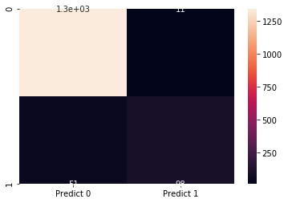

```python
cm=metrics.confusion_matrix(y_test, y_predict, labels=[0, 1])

df_cm = pd.DataFrame(cm, index = [i for i in ["0","1"]],
                  columns = [i for i in ["Predict 0","Predict 1"]])

sns.heatmap(df_cm,annot=True)
cm
```

```python
print('Recall or Sensitivity:',metrics.recall_score(y_test, y_predict))
```

```
Recall or Sensitivity: 0.6577181208053692
```

```python
print('Precision:',metrics.precision_score(y_test, y_predict))
```

```
Precision: 0.8990825688073395
```